# STAT 425 Assignment 7

**Due Tuesday, May 4, 11:59 pm.** Submit through Moodle.

## Name: Kimmy Liu

### Netid: zl32

Submit your computational work both as an R markdown (*.Rmd) document and as a pdf, along with any files needed to run the code. Embed your answers to each problem in the document below after the question statement. If you have hand-written work, please scan or take pictures of it and include in a pdf file, ideally combined with your pdf output file from R Markdown.

**Most relevant class notes:** 10.1.TwoWayAnova1, 10.2.TwoWayAnova2, 11.1.ExperimentalDesign1, 11.2.ExperimentalDesign2

## Problem 1

The data set in comes from an experiment described in the documentation as follows:

In this problem, we will ignore the subject effects, and perform the two-way ANOVA analysis of the response score as a function of and as if the experiment had completely randomized design. In Problem 2, for comparison, we will perform the more proper analysis that accounts for the subject as a blocking variable.

**a)** Here is a way to count how many observations fall in each combination of the two treatment factors:

```r
library(faraway)
xtabs(~Surface+Vision, data=ctsib)
```

```
##        Vision
## Surface closed dome open
##    foam     80   80   80
##    norm     80   80   80
```

Because the design is balanced across all 6 factor combinations, we can do the balanced two-way ANOVA analysis. Here is the ANOVA table for the model with main effects and interactions.

```r
modCRD = lm(CTSIB~Surface*Vision, data=ctsib)
summary(aov(modCRD))
```

```
##                 Df Sum Sq Mean Sq F value Pr(>F)
## Surface          1  58.10   58.10 297.132 <2e-16 ***
## Vision           2  36.84   18.42  94.193 <2e-16 ***
## Surface:Vision   2   0.20    0.10   0.522  0.594
## Residuals      474  92.69    0.20
## ---
## Signif. codes:  0 '***' 0.001 '**' 0.01 '*' 0.05 '.' 0.1 ' ' 1
```

Are there significant interactions? Explain.

**Answer:** There are no significant interactions since the p-value for surface:vision is 0.594>0.05

**b)** Here is how we can get one of the two possible interaction plots for these data.

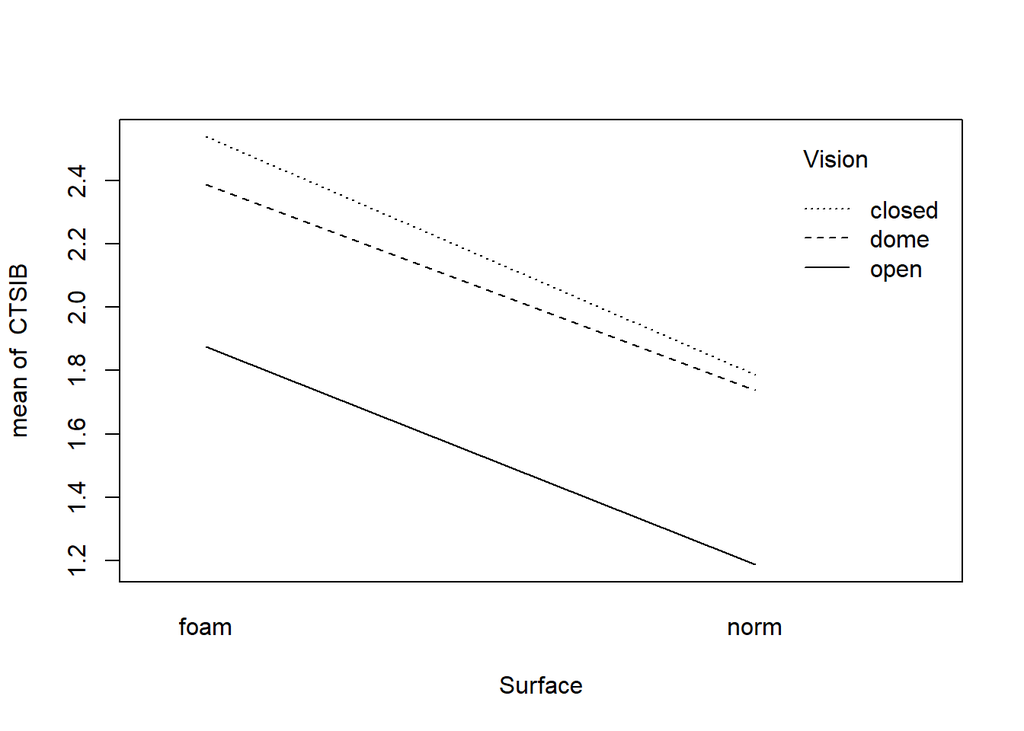

```r
with(ctsib, interaction.plot(x.factor=Surface, trace.factor=Vision, response=CTSIB))
```

Provide the other interaction plot, with on the x-axis, and describe what the plots suggest about how the mean balance scores vary across the different combinations of Vision and Surface.

**Answer:**

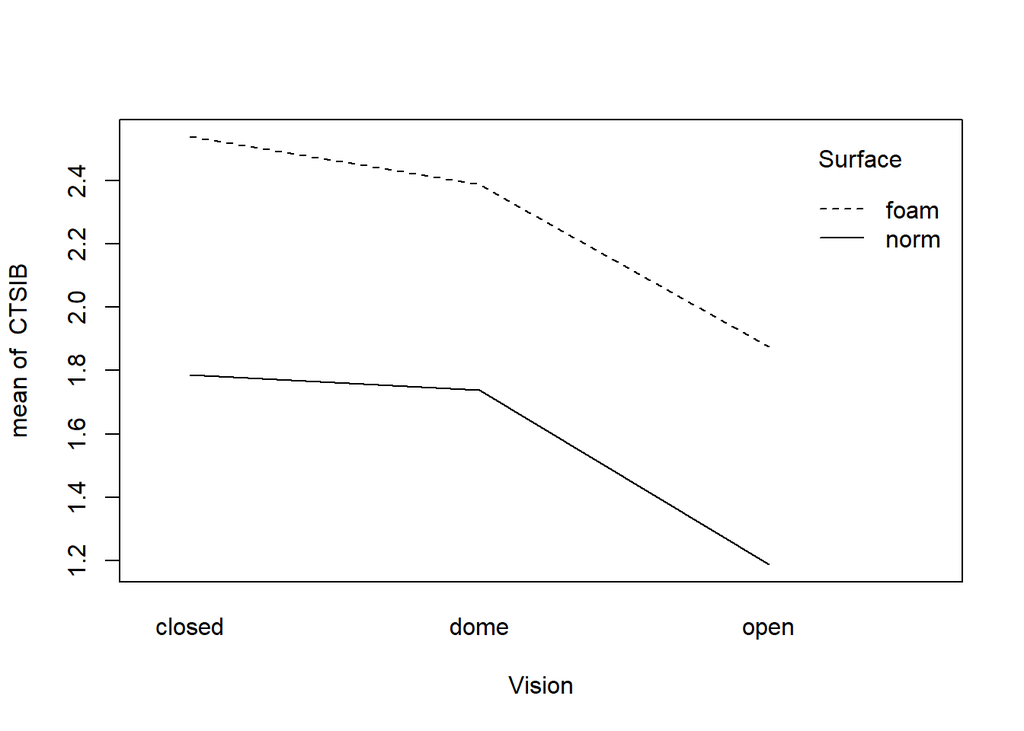

```r
with(ctsib, interaction.plot(x.factor=Vision, trace.factor=Surface, response=CTSIB))
```

From plot with Surface on the x-axis we can see that foam surface has higher mean of CTSIB compared to norm surface with same vision factor and when the surface factor is same, the mean of CTSIB from higher to lower among vision factor is closed>dome>open.

From plot with vision on the x-axis we can see same result as stated above.

**c)** Fit the additive model (main effects only for and ), and show the corresponding analysis of variance table. Are the main effects significant?

**Answer:**

```r
mod.additive = lm(CTSIB~Surface+Vision, data = ctsib)
anova(mod.additive)
```

|  | Df | Sum Sq | Mean Sq | F value | Pr(>F) |
| --- | --- | --- | --- | --- | --- |
| Surface | 1 | 58.10208 | 58.1020833 | 297.72952 | 3.589914e-52 |
| Vision | 2 | 36.83750 | 18.4187500 | 94.38226 | 2.988905e-35 |
| Residuals | 476 | 92.89167 | 0.1951506 | NA | NA |

Yes, the main effects are both significant since they both have very small p-value that <<0.05

**d)** Display the additive model summary that includes the coefficient estimates and standard errors. What are the reference categories for and ?

**Answer:**

```r
summary(mod.additive)
```

```
##
## Call:
## lm(formula = CTSIB ~ Surface + Vision, data = ctsib)
##
## Residuals:
##     Min      1Q  Median      3Q     Max
## -0.8792 -0.4104  0.1208  0.2854  1.4896
##
## Coefficients:
##             Estimate Std. Error t value Pr(>|t|)
## (Intercept)  2.51042    0.04033  62.252   <2e-16 ***
## Surfacenorm -0.69583    0.04033 -17.255   <2e-16 ***
## Visiondome  -0.10000    0.04939  -2.025   0.0435 *
## Visionopen  -0.63125    0.04939 -12.781   <2e-16 ***
## ---
## Signif. codes:  0 '***' 0.001 '**' 0.01 '*' 0.05 '.' 0.1 ' ' 1
##
## Residual standard error: 0.4418 on 476 degrees of freedom
## Multiple R-squared:  0.5055, Adjusted R-squared:  0.5023
## F-statistic: 162.2 on 3 and 476 DF,  p-value: < 2.2e-16
```

The reference categories for surface and vision is foam and closed.

**e)** Perform the Tukey honest significant difference analysis of the two treatment factors, based on the additive model. Which Surface and Vision level differences are statistically significant, controlling the family-wise false postive rate at 0.05?

**Answer:**

```r
TukeyHSD(aov(CTSIB~Surface+Vision, data = ctsib))
```

```
##   Tukey multiple comparisons of means
##     95% family-wise confidence level
##
## Fit: aov(formula = CTSIB ~ Surface + Vision, data = ctsib)
##
## $Surface
##                 diff       lwr        upr p adj
## norm-foam -0.6958333 -0.775074 -0.6165927     0
##
## $Vision
##                 diff        lwr         upr     p adj
## dome-closed -0.10000 -0.2161194  0.01611942 0.1074035
## open-closed -0.63125 -0.7473694 -0.51513058 0.0000000
## open-dome   -0.53125 -0.6473694 -0.41513058 0.0000000
```

norm-foam for surface and open-closed, open-dome for vision differences are statistically significant since their p-value is less than 0.05

## Problem 2

The Problem 1 analysis of the data is technically incorrect, because we expect the 12 measurements from each subject to be more closely related (correlated) than observations between subjects. In other words, is a blocking variable. The subject id is a number, but we should treat it as a factor (categorical label) variable. Therefore, in this experiment we have 40 blocks (the subjects), and 2 observations for each of the 6 treatment combinations within each block. Here are the numbers of observations per cell for the first 3 subjects (blocks), so you can see the design:

```r
xtabs(~Surface+Vision+as.factor(Subject), data=ctsib)[,,1:3]
```

```
## , , as.factor(Subject) = 1
##
##        Vision
## Surface closed dome open
##    foam      2    2    2
##    norm      2    2    2
##
## , , as.factor(Subject) = 2
##
##        Vision
## Surface closed dome open
##    foam      2    2    2
##    norm      2    2    2
##
## , , as.factor(Subject) = 3
##
##        Vision
## Surface closed dome open
##    foam      2    2    2
##    norm      2    2    2
```

**a)** Here is the ANOVA table for the model that adds the blocking variable as a main effect in addition to the main effects and interactions between the two treatment factors:

```r
modRCBD = lm(CTSIB~as.factor(Subject)+Surface*Vision, data=ctsib)
summary(aov(modRCBD))
```

```
##                     Df Sum Sq Mean Sq F value Pr(>F)
## as.factor(Subject)  39  38.75    0.99   8.012 <2e-16 ***
## Surface              1  58.10   58.10 468.569 <2e-16 ***
## Vision               2  36.84   18.42 148.539 <2e-16 ***
## Surface:Vision       2   0.20    0.10   0.823   0.44
## Residuals          435  53.94    0.12
## ---
## Signif. codes:  0 '***' 0.001 '**' 0.01 '*' 0.05 '.' 0.1 ' ' 1
```

Are there significant interactions? Explain.

**Answer:** No, since the p-value for surface:vision is larger than 0.05

**b)** Comparing the ANOVA table part 2a) with the Anova table in Problem 1a), which sums of squares have changed and which ones remain the same? Same question for the different F values, how did each of them change (larger, smaller, unchanged)?

**Answer:** 1(a):

```r
modCRD = lm(CTSIB~Surface*Vision, data=ctsib)
summary(aov(modCRD))
```

```
##                 Df Sum Sq Mean Sq F value Pr(>F)
## Surface          1  58.10   58.10 297.132 <2e-16 ***
## Vision           2  36.84   18.42  94.193 <2e-16 ***
## Surface:Vision   2   0.20    0.10   0.522  0.594
## Residuals      474  92.69    0.20
## ---
## Signif. codes:  0 '***' 0.001 '**' 0.01 '*' 0.05 '.' 0.1 ' ' 1
```

As we can see, Residuals sum of square has changed while surface, vision and surface:vision hasn’t changed. F values for surface change larger F values for vision change larger F values for surface:vision change larger

**c)** Fit the additive model (main effects only for , and ), and show the corresponding analysis of variance table. Are the main effects significant? How have the F values of the main effects for and changed compared with the results in Problem 1c)?

**Answer:**

```r
mod.add = lm(CTSIB~as.factor(Subject)+Surface+Vision, data=ctsib)
anova(mod.add)
```

|  | Df | Sum Sq | Mean Sq | F value | Pr(>F) |
| --- | --- | --- | --- | --- | --- |
| as.factor(Subject) | 39 | 38.74792 | 0.9935363 | 8.018938 | 9.815994e-32 |
| Surface | 1 | 58.10208 | 58.1020833 | 468.948132 | 3.480476e-71 |
| Vision | 2 | 36.83750 | 18.4187500 | 148.659702 | 5.614621e-50 |
| Residuals | 437 | 54.14375 | 0.1238987 | NA | NA |

All the main effects are significant with very small p-value.

1(c):

```r
mod.additive = lm(CTSIB~Surface+Vision, data = ctsib)
anova(mod.additive)
```

|  | Df | Sum Sq | Mean Sq | F value | Pr(>F) |
| --- | --- | --- | --- | --- | --- |
| Surface | 1 | 58.10208 | 58.1020833 | 297.72952 | 3.589914e-52 |
| Vision | 2 | 36.83750 | 18.4187500 | 94.38226 | 2.988905e-35 |
| Residuals | 476 | 92.89167 | 0.1951506 | NA | NA |

Compared to 1(c), the F value for surface becomes larger and F value for vision also becomes larger.

**d)** Compute the ratio of the residual standard error $\hat{\sigma}$ for the model in Part 1c to the residual standard error for the model in Part 2c. What does this say about the relative efficiency of the completely randomized design compared with the randomized blocks design?

**Answer:**

```r
summary(mod.additive)$sigma/summary(mod.add)$sigma
```

```
## [1] 1.255022
```

Since the ratio is bigger than 1, we can tell that the relative efficiency of the completely randomized design is worse than the randomized blocks design. Smaller residual standard error means better predictions.

**e)** Using the additive model that included the subject as a blocking variable, redo the Tukey honest significant difference analysis of the two treatment factors, and . Which Surface and Vision level differences are statistically significant, controlling the family-wise false postive rate at 0.05? Hint: if using the TukeyHSD function, include the argument to obtain results for those factors only and not show the $40*39/2=780$ blocking variable differences, which are not of interest.

**Answer:**

```r
TukeyHSD(aov(CTSIB~as.factor(Subject)+Surface+Vision,  data = ctsib), which=c("Surface", "Vision"))
```

```
##   Tukey multiple comparisons of means
##     95% family-wise confidence level
##
## Fit: aov(formula = CTSIB ~ as.factor(Subject) + Surface + Vision, data = ctsib)
##
## $Surface
##                 diff        lwr        upr p adj
## norm-foam -0.6958333 -0.7589865 -0.6326801     0
##
## $Vision
##                 diff        lwr          upr     p adj
## dome-closed -0.10000 -0.1925497 -0.007450271 0.0305677
## open-closed -0.63125 -0.7237997 -0.538700271 0.0000000
## open-dome   -0.53125 -0.6237997 -0.438700271 0.0000000
```

From the result we can see that all pairwise that norm-foam, dome-closed, open-closed and open-dome differences are statistically significant at level 0.05.